# Birth Weight Analysis

The file birthwt (package MASS) has data on risk factors associated with low birth weight.

Question: is maternal weight before pregnancy (variable lwt) a good predictor of birth weight (bwt)?

1. Run a linear regression of birth weight (the outcome y) on maternal weight (the predictor x). What is the result? Is the regression signficant?

The following is the result of the linear regression. I have to look at the line which describes the coefficient b. b = 4.429, t = 2.585, pvalue = 0.0105. t > 2 and pvalue < 0.05, so we can assume that the linear regression is significant (i.e. y depends on x).

```r
summary(regression)
```

```
Call:
lm(formula = birthwt$bwt ~ birthwt$lwt)

Residuals:
     Min       1Q   Median       3Q      Max
-2192.12  -497.97    -3.84   508.32  2075.60

Coefficients:
            Estimate Std. Error t value Pr(>|t|)
(Intercept) 2369.624    228.493  10.371   <2e-16 ***
birthwt$lwt    4.429      1.713   2.585   0.0105 *
---
Signif. codes:  0 ‘***’ 0.001 ‘**’ 0.01 ‘*’ 0.05 ‘.’ 0.1 ‘ ’ 1

Residual standard error: 718.4 on 187 degrees of freedom
Multiple R-squared:  0.0345,    Adjusted R-squared:  0.02933
F-statistic: 6.681 on 1 and 187 DF,  p-value: 0.0105
```

2. What is the effect of maternal weight on birth weight? What does the slope say?

The slope is b = 4.429. b is positive, and this means that there is a positive effect of maternal weight on birth weight. If mum has an high weight, her child is more likely to have a higher weight.

4. Plot birth weight against maternal weight.

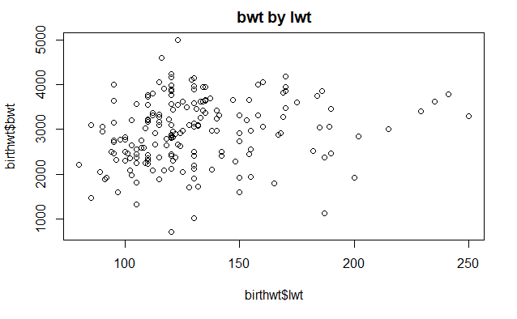

Now, the binary variable low indicates whether a child was born with low birth weight (low=1) or not (low=0).

We want to test whether the variables (1) maternal age (age), (2) maternal weight (lwt), and (3) smoking (smoke) affect the probability of low birth weight.

1. Run a logistic regression of low on the three factors above, plus all interactions. Paste the output representing the maximal model; that’s the regression before optimisation (i.e. the original model). What is the AIC of the maximal model?

This is the output representing the maximal model, where yhe AIC before optimisation is AIC = 235.32:

```r
summary(model.low)
```

```
Call:
glm(formula = low ~ age * lwt * smoke, family = binomial, data = birthwt)

Deviance Residuals:
    Min       1Q   Median       3Q      Max
-1.1869  -0.9560  -0.6883   1.2980   2.2123

Coefficients:
               Estimate Std. Error z value Pr(>|z|)
(Intercept)   -2.002038   6.388079  -0.313    0.754
age            0.165939   0.292696   0.567    0.571
lwt            0.020110   0.051570   0.390    0.697
smoke          4.767676   8.043539   0.593    0.553
age:lwt       -0.001872   0.002359  -0.793    0.428
age:smoke     -0.264060   0.354463  -0.745    0.456
lwt:smoke     -0.044261   0.063977  -0.692    0.489
age:lwt:smoke  0.002610   0.002805   0.931    0.352

(Dispersion parameter for binomial family taken to be 1)

    Null deviance: 234.67  on 188  degrees of freedom
Residual deviance: 219.32  on 181  degrees of freedom
AIC: 235.32

Number of Fisher Scoring iterations: 5
```

The AIC of the optimised model is AIC = 230.34, and it is obtained maintaing only individual terms lwt and smoke.

```r
summary(step(model.low))
```

```
Start:  AIC=235.32
low ~ age * lwt * smoke

                Df Deviance    AIC
- age:lwt:smoke  1   220.25 234.25
<none>               219.32 235.32

Step:  AIC=234.25
low ~ age + lwt + smoke + age:lwt + age:smoke + lwt:smoke

            Df Deviance    AIC
- age:lwt    1   220.26 232.26
- age:smoke  1   221.12 233.12
- lwt:smoke  1   221.62 233.62
<none>           220.25 234.25

Step:  AIC=232.26
low ~ age + lwt + smoke + age:smoke + lwt:smoke

            Df Deviance    AIC
- age:smoke  1   221.12 231.12
- lwt:smoke  1   221.63 231.63
<none>           220.26 232.26

Step:  AIC=231.12
low ~ age + lwt + smoke + lwt:smoke

            Df Deviance    AIC
- age        1   222.37 230.37
- lwt:smoke  1   222.88 230.88
<none>           221.12 231.12

Step:  AIC=230.37
low ~ lwt + smoke + lwt:smoke

            Df Deviance    AIC
- lwt:smoke  1   224.34 230.34
<none>           222.37 230.37

Step:  AIC=230.34
```

[output cut: 14 more lines]

```
Coefficients:
            Estimate Std. Error z value Pr(>|z|)
(Intercept)  0.62200    0.79592   0.781   0.4345
lwt         -0.01332    0.00609  -2.188   0.0287 *
smoke        0.67667    0.32470   2.084   0.0372 *
---
Signif. codes:  0 ‘***’ 0.001 ‘**’ 0.01 ‘*’ 0.05 ‘.’ 0.1 ‘ ’ 1

(Dispersion parameter for binomial family taken to be 1)

    Null deviance: 234.67  on 188  degrees of freedom
Residual deviance: 224.34  on 186  degrees of freedom
AIC: 230.34

Number of Fisher Scoring iterations: 4
```

3. Finally, interpret the meaning of all factors left in the optimal model.

For lwt: b = -0.01, so log(odds ratio) = -0.01, so odds ratio = exp(-0.01) = 0.9867683. This means that an higher maternal weight slightly decreases the chances of the child being with low birth weight.

For smoke: b = 0.67667, so log(odds ratio) = 0.67667, so odds ratio = exp(0.67667) = 1.967316. This means that smoking considerably increases the chances of the child being with low birth weight (almost doubles them), compared to those with non-smoking mothers.

We could calculate also the corresponding probabilities: for Lwt 49,6% (almost 50% 50%, in line with previous consideration), for smoke 66,29% (is much more likely than unlikely to be underweight if you mother is smoking).